# Tutorial_2a

Sven Panis

2024-11-18

In this Tutorial 2a we plot priors for the logit and cloglog link functions, build Bayesian hazard regression models for the first experiment of Panis and Schmidt (2016) using only the no-mask trials (prime = blank, congruent, or incongruent), and visualize the posterior distributions of the effects of congruent and incongruent prime types, relative to blank prime trials for the selected model.

Content:

1. Load libraries.
2. Load and wrangle the person-trial-bin data set that we saved in Tutorial 1a.
3. Plot the logit and complementary log-log (cloglog) link functions.
4. Visualize different prior distributions on the logit and cloglog scales.
5. Fit hazard models.
6. Compare models using loo and waic.
7. Display effects for the selected model.

# 1. Load the libraries that we will be using.

```r
pkg <- c("cmdstanr", "standist", "tidyverse", "RColorBrewer", "patchwork",
         "brms", "tidybayes", "bayesplot", "future", "parallel")

lapply(pkg, library, character.only = TRUE)
```

```
## This is cmdstanr version 0.8.1.9000
```

```
## - CmdStanR documentation and vignettes: mc-stan.org/cmdstanr
```

```
## - CmdStan path: /Users/spanis/.cmdstan/cmdstan-2.35.0
```

```
## - CmdStan version: 2.35.0
```

[output not shown]

Set options.

```r
options(brms.backend = "cmdstanr",
        mc.cores = parallel::detectCores(),
        future.fork.enable = TRUE,
        future.rng.onMisuse = "ignore") ## automatically set in RStudio

supportsMulticore()
detectCores()
```

```r
packageVersion("cmdstanr")
devtools::session_info("rstan")
```

# 2. Load and wrangle the person-trial-bin data set that we saved in Tutorial 1a.

```r
ptb_data <- read_csv("Tutorial_1_descriptive_stats/data/inputfile_hazard_modeling.csv")
print(ptb_data,n=30)
```

```
## # A tibble: 26,602 × 7
##      pid    bl    tr trial condition   period event
##    <dbl> <dbl> <dbl> <dbl> <chr>        <dbl> <dbl>
##  1     1     2     4     4 congruent        1     0
##  2     1     2     4     4 congruent        2     0
##  3     1     2     4     4 congruent        3     0
##  4     1     2     4     4 congruent        4     0
##  5     1     2     4     4 congruent        5     0
##  6     1     2     4     4 congruent        6     0
##  7     1     2     4     4 congruent        7     0
##  8     1     2     4     4 congruent        8     0
##  9     1     2     4     4 congruent        9     0
## 10     1     2     4     4 congruent       10     0
## 11     1     2     4     4 congruent       11     0
## 12     1     2     4     4 congruent       12     1
```

[output cut: 19 more lines]

```r
summary(ptb_data) # 26602 rows: 6 participants, trial, 3 conditions, 15 periods, and event indicator (0/1)
```

```
##       pid              bl             tr            trial
##  Min.   :1.000   Min.   : 2.0   Min.   : 1.00   Min.   :   1.0
##  1st Qu.:2.000   1st Qu.:21.0   1st Qu.: 6.00   1st Qu.: 419.0
##  Median :3.000   Median :36.0   Median :11.00   Median : 767.0
##  Mean   :3.508   Mean   :37.4   Mean   :11.49   Mean   : 790.3
##  3rd Qu.:5.000   3rd Qu.:56.0   3rd Qu.:17.00   3rd Qu.:1205.0
##  Max.   :6.000   Max.   :71.0   Max.   :22.00   Max.   :1540.0
##   condition             period           event
##  Length:26602       Min.   : 1.000   Min.   :0.0000
##  Class :character   1st Qu.: 3.000   1st Qu.:0.0000
##  Mode  :character   Median : 5.000   Median :0.0000
##                     Mean   : 5.591   Mean   :0.1009
##                     3rd Qu.: 8.000   3rd Qu.:0.0000
##                     Max.   :15.000   Max.   :1.0000
```

Prepare the data set.

```r
# select analysis time range: (200,600] with 10 bins (time bin ranks 6 to 15)
ptb_data <- ptb_data %>% filter(period > 5)

# create factor condition, with "blank" as the reference level
ptb_data <- ptb_data %>% mutate(condition = factor(condition, labels = c("blank", "congruent","incongruent")))

# center TIME (period) on bin 9, and trial on trial 1000 and rescale; Add dummy variables for each bin.
ptb_data <- ptb_data %>%
        mutate(period_9 = period - 9,
               trial_c = (trial - 1000)/1000,
               d6  = if_else(period == 6, 1, 0),
               d7  = if_else(period == 7, 1, 0),
               d8  = if_else(period == 8, 1, 0),
               d9  = if_else(period == 9, 1, 0),
               d10 = if_else(period == 10, 1, 0),
               d11 = if_else(period == 11, 1, 0),
               d12 = if_else(period == 12, 1, 0),
               d13 = if_else(period == 13, 1, 0),
               d14 = if_else(period == 14, 1, 0),
               d15 = if_else(period == 15, 1, 0))

head(ptb_data,n=17)
```

```
## # A tibble: 17 × 19
##      pid    bl    tr trial condition   period event period_9 trial_c    d6    d7
##    <dbl> <dbl> <dbl> <dbl> <fct>        <dbl> <dbl>    <dbl>   <dbl> <dbl> <dbl>
##  1     1     2     4     4 congruent        6     0       -3  -0.996     1     0
##  2     1     2     4     4 congruent        7     0       -2  -0.996     0     1
##  3     1     2     4     4 congruent        8     0       -1  -0.996     0     0
##  4     1     2     4     4 congruent        9     0        0  -0.996     0     0
##  5     1     2     4     4 congruent       10     0        1  -0.996     0     0
##  6     1     2     4     4 congruent       11     0        2  -0.996     0     0
##  7     1     2     4     4 congruent       12     1        3  -0.996     0     0
##  8     1     2     5     5 incongruent      6     0       -3  -0.995     1     0
##  9     1     2     5     5 incongruent      7     0       -2  -0.995     0     1
## 10     1     2     5     5 incongruent      8     0       -1  -0.995     0     0
## 11     1     2     5     5 incongruent      9     0        0  -0.995     0     0
## 12     1     2     5     5 incongruent     10     0        1  -0.995     0     0
## 13     1     2     5     5 incongruent     11     0        2  -0.995     0     0
## 14     1     2     5     5 incongruent     12     0        3  -0.995     0     0
## 15     1     2     5     5 incongruent     13     0        4  -0.995     0     0
## 16     1     2     5     5 incongruent     14     0        5  -0.995     0     0
## 17     1     2     5     5 incongruent     15     1        6  -0.995     0     0
## # ℹ 8 more variables: d8 <dbl>, d9 <dbl>, d10 <dbl>, d11 <dbl>, d12 <dbl>,
## #   d13 <dbl>, d14 <dbl>, d15 <dbl>
```

```r
summary(ptb_data)
```

```
##       pid              bl              tr            trial
##  Min.   :1.000   Min.   : 2.00   Min.   : 1.00   Min.   :   1.0
##  1st Qu.:2.000   1st Qu.:20.00   1st Qu.: 6.00   1st Qu.: 405.0
##  Median :3.000   Median :36.00   Median :11.00   Median : 764.0
##  Mean   :3.516   Mean   :37.11   Mean   :11.54   Mean   : 784.1
##  3rd Qu.:5.000   3rd Qu.:56.00   3rd Qu.:17.00   3rd Qu.:1204.0
##  Max.   :6.000   Max.   :71.00   Max.   :22.00   Max.   :1540.0
##        condition        period          event           period_9
##  blank      :6401   Min.   : 6.00   Min.   :0.0000   Min.   :-3.0000
##  congruent  :2642   1st Qu.: 7.00   1st Qu.:0.0000   1st Qu.:-2.0000
##  incongruent:3797   Median : 8.00   Median :0.0000   Median :-1.0000
##                     Mean   : 8.37   Mean   :0.2023   Mean   :-0.6296
##                     3rd Qu.:10.00   3rd Qu.:0.0000   3rd Qu.: 1.0000
##                     Max.   :15.00   Max.   :1.0000   Max.   : 6.0000
##     trial_c              d6              d7              d8
##  Min.   :-0.9990   Min.   :0.000   Min.   :0.000   Min.   :0.0000
##  1st Qu.:-0.5950   1st Qu.:0.000   1st Qu.:0.000   1st Qu.:0.0000
##  Median :-0.2360   Median :0.000   Median :0.000   Median :0.0000
##  Mean   :-0.2159   Mean   :0.208   Mean   :0.198   Mean   :0.1794
##  3rd Qu.: 0.2040   3rd Qu.:0.000   3rd Qu.:0.000   3rd Qu.:0.0000
##  Max.   : 0.5400   Max.   :1.000   Max.   :1.000   Max.   :1.0000
##        d9             d10              d11               d12
##  Min.   :0.000   Min.   :0.0000   Min.   :0.00000   Min.   :0.00000
##  1st Qu.:0.000   1st Qu.:0.0000   1st Qu.:0.00000   1st Qu.:0.00000
##  Median :0.000   Median :0.0000   Median :0.00000   Median :0.00000
##  Mean   :0.153   Mean   :0.1113   Mean   :0.06667   Mean   :0.03956
##  3rd Qu.:0.000   3rd Qu.:0.0000   3rd Qu.:0.00000   3rd Qu.:0.00000
##  Max.   :1.000   Max.   :1.0000   Max.   :1.00000   Max.   :1.00000
##       d13               d14               d15
##  Min.   :0.00000   Min.   :0.00000   Min.   :0.000000
##  1st Qu.:0.00000   1st Qu.:0.00000   1st Qu.:0.000000
##  Median :0.00000   Median :0.00000   Median :0.000000
##  Mean   :0.02274   Mean   :0.01301   Mean   :0.008411
##  3rd Qu.:0.00000   3rd Qu.:0.00000   3rd Qu.:0.000000
##  Max.   :1.00000   Max.   :1.00000   Max.   :1.000000
```

```r
# 6 subjects
# condition: blank (6401), congruent (2642), incongruent (3797)
# period_9: -3 to 6
# trial_c: -0.999 to 0.540
```

# 3. Plot the logit and complementary log-log (cloglog) link functions.

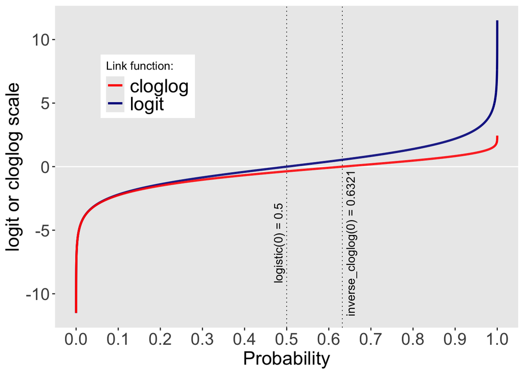

```r
probability <- (1:99999)/100000
logistic <- function(x) { return( 1/(1+exp(-1*x)) )}
logit    <- function(x) { return( log(x/(1-x)) )}
inverse_cloglog <- function(x) { return( 1-(exp(-1*exp(x))) )}
cloglog         <- function(x) { return( log(-1*log(1-x)) )}

cloglog_prob <- cloglog(probability)
logit_prob <- logit(probability)
dataplot <- cbind(probability,cloglog_prob,logit_prob)

ggplot() +
  geom_hline(yintercept=0, color="white") +
  geom_line(data=dataplot,aes(y=logit_prob,x=probability,colour="logit"),linewidth=1) +
  geom_line(data=dataplot,aes(y=cloglog_prob,x=probability,colour="cloglog"),linewidth=1) +
  scale_color_manual(name = "Link function:", values = c("logit" = "darkblue", "cloglog" = "red")) +
  geom_vline(xintercept = logistic(0), linetype="dotted", linewidth = 0.3) +
  geom_vline(xintercept = inverse_cloglog(0), linetype="dotted", linewidth = 0.3) +
  annotate("text", x = logistic(0)-.02, y = -6, label = "logistic(0) = 0.5", angle = 90, size=4) +
  annotate("text", x = inverse_cloglog(0)+.02, y = -6, label = "inverse_cloglog(0) = 0.6321", angle=90,size=4) +
  scale_x_continuous(n.breaks=10, limits = c(0,1), ) +
  labs(x = "Probability",
        y = "logit or cloglog scale") +
  theme(panel.grid = element_blank(),
        axis.text=element_text(size=16),
        axis.title=element_text(size=18),
      #  legend.position="top",
        legend.text = element_text(size=18),
      legend.position = "inside",
        legend.position.inside=c(.2,.75),
      legend.background = element_rect(fill="white") )
```

```r
ggsave("Tutorial_2_Bayesian/figures/linkfunctions.png", width = 8, height = 8, dpi = 300)
```

# 4. Visualize different prior distributions on the logit and cloglog scales.

To gain a sense of what prior logit values would approximate a uniform distribution on the probability (i.e., discrete-time hazard) scale, Solomon Kurz simulated a large number of draws from the Uniform(0,1) distribution, converted those draws to the log-odds metric, and fitted a Student’s t model. Here we do the same for prior cloglog values: simulate a large number of draws from U(0,1), convert them to the cloglog metric, and fit a skew-normal model (due to the asymmetry of the cloglog link function), to gain a sense of what prior cloglog values would approximate a uniform distribution on the probability (i.e., discrete-time hazard) scale.

## Simulate, convert, and fit.

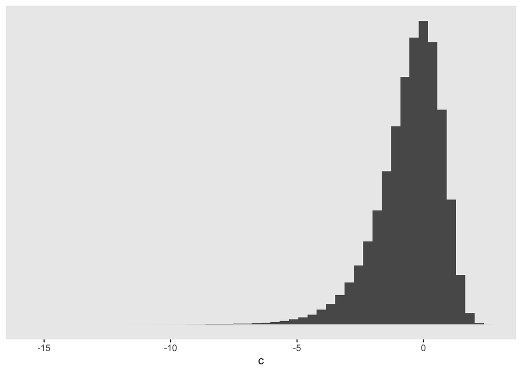

```r
set.seed(11)

logit    <- function(x) { return( log(x/(1-x)) )}
cloglog  <- function(x) { return( log(-1*log(1-x)) )}

# generate draws from U(0,1) and convert
dat <-
  tibble(p = runif(1e6, 0, 1)) %>%
  mutate(g = logit(p),
         c = cloglog(p))
# display
dat %>%
  ggplot(aes(x = c)) +
  geom_histogram(bins = 50) +
  scale_y_continuous(NULL, breaks = NULL) +
  theme(panel.grid = element_blank())
```

```r
# fit model
fit_skewN <-
  brm(data = dat,
      family = skew_normal(),
      c ~ 1,
      chains = 4, cores = 4,
      file = "Tutorial_2_Bayesian/models/fit_skewN")
```

```r
fit_skewN <- readRDS("Tutorial_2_Bayesian/models/fit_skewN.rds")
summary(fit_skewN)
```

```
##  Family: skew_normal
##   Links: mu = identity; sigma = identity; alpha = identity
## Formula: c ~ 1
##    Data: dat (Number of observations: 1000000)
##   Draws: 4 chains, each with iter = 2000; warmup = 1000; thin = 1;
##          total post-warmup draws = 4000
##
## Regression Coefficients:
##           Estimate Est.Error l-95% CI u-95% CI Rhat Bulk_ESS Tail_ESS
## Intercept    -0.59      0.00    -0.59    -0.59 1.00     3127     2835
##
## Further Distributional Parameters:
##       Estimate Est.Error l-95% CI u-95% CI Rhat Bulk_ESS Tail_ESS
## sigma     1.26      0.00     1.26     1.26 1.00     2951     2825
## alpha    -4.22      0.01    -4.25    -4.19 1.00     1142     1319
##
## Draws were sampled using sample(hmc). For each parameter, Bulk_ESS
## and Tail_ESS are effective sample size measures, and Rhat is the potential
## scale reduction factor on split chains (at convergence, Rhat = 1).
```

Now we can reverse the process. We simulate from the skew-Normal distribution based on the posterior means for mu, sigma, and alpha, and then convert the results into the probability (i.e., discrete-time hazard) metric.

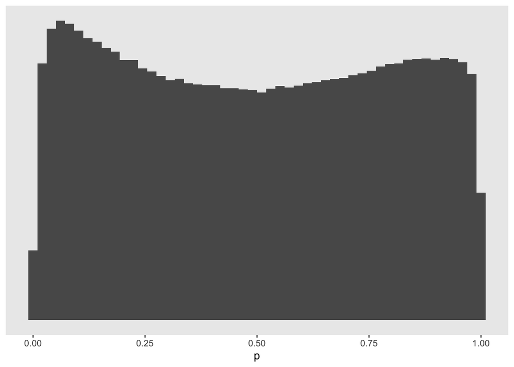

```r
set.seed(11)

inverse_cloglog <- function(x) { return( 1-(exp(-1*exp(x))) )}

tibble(c = rskew_normal(1e6, mu=-0.59, sigma = 1.26, alpha = -4.22) ) %>%
  mutate(p = inverse_cloglog(c)) %>%
  ggplot(aes(x = p)) +
  geom_histogram(bins = 50) +
  scale_y_continuous(NULL, breaks = NULL) +
  theme(panel.grid = element_blank())
```

## Visualize how seven prior distributions on the logit and/or cloglog scales look on the probability scale.

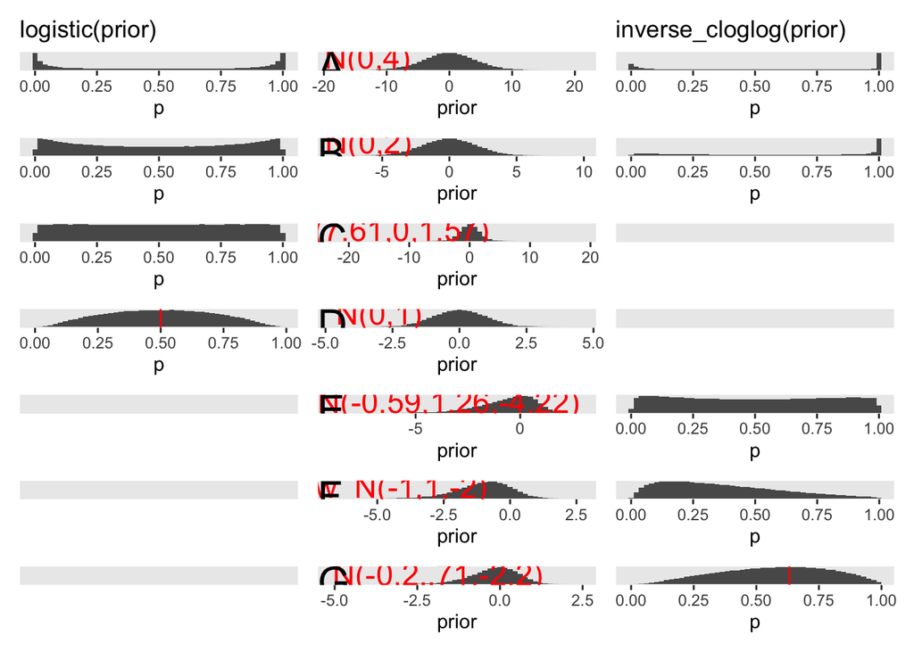

```r
logistic <- function(x) { return( 1/(1+exp(-1*x)) )}
logit    <- function(x) { return( log(x/(1-x)) )}
inverse_cloglog <- function(x) { return( 1-(exp(-1*exp(x))) )}
cloglog    <- function(x) { return( log(-1*log(1-x)) )}

set.seed(23)

# A N(0,4) prior on the logit and cloglog scales pushes mass to probabilities of 0 and 1
pr1 <- tibble(prior = rnorm(1e6, mean = 0, sd = 4)) %>%
  ggplot(aes(x = prior)) +
  geom_histogram(bins = 50) +
  scale_y_continuous(NULL, breaks = NULL) +
  annotate(geom="text", x=-13, y=60000, label="N(0,4)",
              color="red", size=6) +
  annotate(geom = 'text', label = 'A', x = -Inf, y = Inf, hjust = 0, vjust = 1, size=8)+
  theme(panel.grid = element_blank())

l1 <- tibble(log_odds = rnorm(1e6, mean = 0, sd = 4)) %>%
  mutate(p = logistic(log_odds)) %>%
  ggplot(aes(x = p)) +
  geom_histogram(bins = 50) +
  scale_y_continuous(NULL, breaks = NULL) +
  ggtitle("logistic(prior)") +
  theme(panel.grid = element_blank())

c1 <- tibble(cloglog_prob = rnorm(1e6, mean = 0, sd = 4)) %>%
  mutate(p = inverse_cloglog(cloglog_prob)) %>%
  ggplot(aes(x = p)) +
  geom_histogram(bins = 50) +
  scale_y_continuous(NULL, breaks = NULL) +
  ggtitle("inverse_cloglog(prior)")+
  theme(panel.grid = element_blank())

# A N(0,2) prior on the logit and cloglog scales pushes mass to probabilities of 0 and/or 1
pr2 <- tibble(prior = rnorm(1e6, mean = 0, sd = 2)) %>%
  ggplot(aes(x = prior)) +
  geom_histogram(bins = 50) +
  scale_y_continuous(NULL, breaks = NULL) +
  annotate(geom="text", x=-6, y=60000, label="N(0,2)",
              color="red", size=6) +
  annotate(geom = 'text', label = 'B', x = -Inf, y = Inf, hjust = 0, vjust = 1, size=8)+
  theme(panel.grid = element_blank())

l2 <- tibble(log_odds = rnorm(1e6, mean = 0, sd = 2)) %>%
  mutate(p = logistic(log_odds)) %>%
  ggplot(aes(x = p)) +
  geom_histogram(bins = 50) +
  scale_y_continuous(NULL, breaks = NULL) +
  theme(panel.grid = element_blank())

c2 <- tibble(cloglog_prob = rnorm(1e6, mean = 0, sd = 2)) %>%
  mutate(p = inverse_cloglog(cloglog_prob)) %>%
  ggplot(aes(x = p)) +
  geom_histogram(bins = 50) +
  scale_y_continuous(NULL, breaks = NULL) +
  theme(panel.grid = element_blank())

# A student-t(df=7.61) prior with scale 1.57 on the logit scale approximates a uniform distribution on the probability scale. This might be a good prior to use for the alpha parameters or Intercept in a logit-hazard model.
pr3 <- tibble(prior = rt(1e6, df = 7.61)* 1.57) %>%
  ggplot(aes(x = prior)) +
  geom_histogram(bins = 50) +
  scale_y_continuous(NULL, breaks = NULL) +
  annotate(geom="text", x=-12, y=140000, label="t(7.61,0,1.57)",
              color="red", size=6) +
  annotate(geom = 'text', label = 'C', x = -Inf, y = Inf, hjust = 0, vjust = 1, size=8)+
  theme(panel.grid = element_blank())

l3 <- tibble(log_odds = rt(1e6, df = 7.61)* 1.57) %>%
  mutate(p = logistic(log_odds)) %>%
  ggplot(aes(x = p)) +
  geom_histogram(bins = 50) +
  scale_y_continuous(NULL, breaks = NULL) +
  theme(panel.grid = element_blank())

c3 <- ggplot()

# A Normal(0,1) prior on the logit scale gently regularizes p towards .5. This might be a good prior to use for the beta parameters in a logit-hazard model.
pr4 <- tibble(prior = rnorm(1e6, mean = 0, sd = 1))%>%
  ggplot(aes(x = prior)) +
  geom_histogram(bins = 50) +
  scale_y_continuous(NULL, breaks = NULL) +
  annotate(geom="text", x=-3, y=60000, label="N(0,1)",
              color="red", size=6) +
  annotate(geom = 'text', label = 'D', x = -Inf, y = Inf, hjust = 0, vjust = 1, size=8)+
  theme(panel.grid = element_blank())

l4 <- tibble(log_odds = rnorm(1e6, mean = 0, sd = 1))%>%
  mutate(p = logistic(log_odds)) %>%
  ggplot(aes(x = p)) +
  geom_histogram(bins = 50) +
  scale_y_continuous(NULL, breaks = NULL) +
  geom_vline(xintercept=logistic(0), color="red") +
  theme(panel.grid = element_blank())

c4 <- ggplot()

# A skew_Normal(-0.59,1.26,-4.22) prior on the cloglog scale approxiates a uniform distr. on the hazard scale. This uninformative prior might be good for the alpha parameters or Intercept in a cloglog-hazard model.
pr5 <- tibble(prior = rskew_normal(1e6, mu=-0.59, sigma = 1.26, alpha = -4.22)) %>%
  ggplot(aes(x = prior)) +
  geom_histogram(bins = 50) +
  scale_y_continuous(NULL, breaks = NULL) +
  annotate(geom="text", x=-5.5, y=55000, label="skew_N(-0.59,1.26,-4.22)",
              color="red", size=6) +
  annotate(geom = 'text', label = 'E', x = -Inf, y = Inf, hjust = 0, vjust = 1, size=8)+
  theme(panel.grid = element_blank())

l5 <- ggplot()

c5 <- tibble(cloglog_prob = rskew_normal(1e6, mu=-0.59, sigma = 1.26, alpha = -4.20)) %>%
  mutate(p = inverse_cloglog(cloglog_prob)) %>%
  ggplot(aes(x = p)) +
  geom_histogram(bins = 50) +
  scale_y_continuous(NULL, breaks = NULL) +
  theme(panel.grid = element_blank())

# The skew_Normal(-1,1,-2) on the cloglog scale is a weakly informative prior for the alpha parameters or Intercept in a cloglog-hazard model because hazard values below .5 more likely than values above .5 in general.
pr6 <- tibble(prior = rskew_normal(1e6, mu=-1, sigma = 1, alpha = -2)) %>%
  ggplot(aes(x = prior)) +
  geom_histogram(bins = 50) +
  scale_y_continuous(NULL, breaks = NULL) +
  annotate(geom="text", x=-5, y=55000, label="skew_N(-1,1,-2)",
              color="red", size=6) +
  annotate(geom = 'text', label = 'F', x = -Inf, y = Inf, hjust = 0, vjust = 1, size=8)+
  theme(panel.grid = element_blank())

l6 <- ggplot()

c6 <- tibble(cloglog_prob = rskew_normal(1e6, mu=-1, sigma = 1, alpha = -2)) %>%
  mutate(p = inverse_cloglog(cloglog_prob)) %>%
  ggplot(aes(x = p)) +
  geom_histogram(bins = 50) +
  scale_y_continuous(NULL, breaks = NULL) +
  theme(panel.grid = element_blank())

# A skew_Normal(-0.2,0.71,-2.2) on the cloglog scale gently regularizes p towards .6321. This might be a good prior to use for the beta parameters in a cloglog-hazard model.
pr7 <- tibble(prior = rskew_normal(1e6, mu=-0.2, sigma = .71, alpha = -2.2)) %>%
  ggplot(aes(x = prior)) +
  geom_histogram(bins = 50) +
  scale_y_continuous(NULL, breaks = NULL) +
  annotate(geom="text", x=-3.2, y=55000, label="skew_N(-0.2,.71,-2.2)",
              color="red", size=6) +
  annotate(geom = 'text', label = 'G', x = -Inf, y = Inf, hjust = 0, vjust = 1, size=8)+
  theme(panel.grid = element_blank())

l7 <- ggplot()

c7 <- tibble(cloglog_prob = rskew_normal(1e6, mu=-0.2, sigma = .71, alpha = -2.2)) %>%
  mutate(p = inverse_cloglog(cloglog_prob)) %>%
  ggplot(aes(x = p)) +
  geom_histogram(bins = 50) +
  geom_vline(xintercept=inverse_cloglog(0), color = "red") +
  scale_y_continuous(NULL, breaks = NULL) +
  theme(panel.grid = element_blank())

(l1 + pr1 + c1) / (l2 + pr2 + c2) / (l3 + pr3 + c3) / (l4 + pr4 + c4)/ (l5 + pr5 + c5) / (l6 + pr6 + c6) / (l7 + pr7 + c7)
```

```r
ggsave("Tutorial_2_Bayesian/figures/plot_of_priors.png", width=14, height=13,dpi=300)
```

# 5. Fit hazard models.

## Model M1: general specification of TIME in the baseline condition (blank prime), and main effects of prime type, and trial number.

### Prepare data for M1

```r
# remove unnecessary columns before fitting a model
M1_data <- ptb_data %>% select(-c(bl,tr,trial,period, period_9,d9)) # 12840 obs.
head(M1_data)
```

```
## # A tibble: 6 × 13
##     pid condition event trial_c    d6    d7    d8   d10   d11   d12   d13   d14
##   <dbl> <fct>     <dbl>   <dbl> <dbl> <dbl> <dbl> <dbl> <dbl> <dbl> <dbl> <dbl>
## 1     1 congruent     0  -0.996     1     0     0     0     0     0     0     0
## 2     1 congruent     0  -0.996     0     1     0     0     0     0     0     0
## 3     1 congruent     0  -0.996     0     0     1     0     0     0     0     0
## 4     1 congruent     0  -0.996     0     0     0     0     0     0     0     0
## 5     1 congruent     0  -0.996     0     0     0     1     0     0     0     0
## 6     1 congruent     0  -0.996     0     0     0     0     1     0     0     0
## # ℹ 1 more variable: d15 <dbl>
```

```r
summary(M1_data)
```

```
##       pid              condition        event           trial_c
##  Min.   :1.000   blank      :6401   Min.   :0.0000   Min.   :-0.9990
##  1st Qu.:2.000   congruent  :2642   1st Qu.:0.0000   1st Qu.:-0.5950
##  Median :3.000   incongruent:3797   Median :0.0000   Median :-0.2360
##  Mean   :3.516                      Mean   :0.2023   Mean   :-0.2159
##  3rd Qu.:5.000                      3rd Qu.:0.0000   3rd Qu.: 0.2040
##  Max.   :6.000                      Max.   :1.0000   Max.   : 0.5400
##        d6              d7              d8              d10
##  Min.   :0.000   Min.   :0.000   Min.   :0.0000   Min.   :0.0000
##  1st Qu.:0.000   1st Qu.:0.000   1st Qu.:0.0000   1st Qu.:0.0000
##  Median :0.000   Median :0.000   Median :0.0000   Median :0.0000
##  Mean   :0.208   Mean   :0.198   Mean   :0.1794   Mean   :0.1113
##  3rd Qu.:0.000   3rd Qu.:0.000   3rd Qu.:0.0000   3rd Qu.:0.0000
##  Max.   :1.000   Max.   :1.000   Max.   :1.0000   Max.   :1.0000
##       d11               d12               d13               d14
##  Min.   :0.00000   Min.   :0.00000   Min.   :0.00000   Min.   :0.00000
##  1st Qu.:0.00000   1st Qu.:0.00000   1st Qu.:0.00000   1st Qu.:0.00000
##  Median :0.00000   Median :0.00000   Median :0.00000   Median :0.00000
##  Mean   :0.06667   Mean   :0.03956   Mean   :0.02274   Mean   :0.01301
##  3rd Qu.:0.00000   3rd Qu.:0.00000   3rd Qu.:0.00000   3rd Qu.:0.00000
##  Max.   :1.00000   Max.   :1.00000   Max.   :1.00000   Max.   :1.00000
##       d15
##  Min.   :0.000000
##  1st Qu.:0.000000
##  Median :0.000000
##  Mean   :0.008411
##  3rd Qu.:0.000000
##  Max.   :1.000000
```

### Set up priors for M1

```r
priors_M1 <- c(
  set_prior("skew_normal(-0.2,0.71,-2.2)", class = "b"),       # weakly informative prior for beta parameters when using cloglog link
  set_prior("skew_normal(-1,1,-2)", class = "b", coef = "d6"),# weakly informative prior for alpha parameters when using cloglog link
  set_prior("skew_normal(-1,1,-2)", class = "b", coef = "d7"),
  set_prior("skew_normal(-1,1,-2)", class = "b", coef = "d8"),
  set_prior("skew_normal(-1,1,-2)", class = "b", coef = "d10"),
  set_prior("skew_normal(-1,1,-2)", class = "b", coef = "d11"),
  set_prior("skew_normal(-1,1,-2)", class = "b", coef = "d12"),
  set_prior("skew_normal(-1,1,-2)", class = "b", coef = "d13"),
  set_prior("skew_normal(-1,1,-2)", class = "b", coef = "d14"),
  set_prior("skew_normal(-1,1,-2)", class = "b", coef = "d15"),
  set_prior("skew_normal(-1,1,-2)", class = "b", coef = "Intercept"),
  set_prior("normal(0, 1)", class = "sd"),                     # prior for standard deviation of random effects
  set_prior("lkj(2)", class = "cor")                           # prior for correlations between random effects
)
```

### Fit model M1.

```r
plan(multicore)

model_M1 <-
   brm(data = M1_data,
       family = binomial(link="cloglog"),
       event | trials(1) ~ 0 + d6 + d7 + d8 + Intercept + d10 + d11 + d12 + d13 + d14 + d15 +
         condition + trial_c +

                   (d6 + d7 + d8 + 1 + d10 + d11 + d12 + d13 + d14 + d15 + condition + trial_c | pid),
       prior = priors_M1,
       chains = 4, cores = 4, iter = 3000, warmup = 1000,
       control = list(adapt_delta = 0.999, step_size = 0.04, max_treedepth = 12),
       seed = 12, init = "0",
       file = "Tutorial_2_Bayesian/models/model_M1")
```

Model_M1 took about 70 minutes on a MacBook Pro (Sonoma 14.6.1 OS, 18GB Memory, M3 Pro Chip).

```r
model_M1 <- readRDS("Tutorial_2_Bayesian/models/model_M1.rds")
summary(model_M1)
fixef(model_M1)
```

## Model M2: third-order polynomical specification of TIME in the baseline condition (blank prime), and main effects of prime types, and trial number.

### Prepare data for M2.

```r
# remove unnecessary columns before fitting a model
M2_data <- ptb_data %>% select(-c(bl,tr,trial,period, d6, d7, d8, d9, d10, d11, d12, d13, d14, d15)) # 12840 obs. of 14 variables
head(M2_data)
```

```
## # A tibble: 6 × 5
##     pid condition event period_9 trial_c
##   <dbl> <fct>     <dbl>    <dbl>   <dbl>
## 1     1 congruent     0       -3  -0.996
## 2     1 congruent     0       -2  -0.996
## 3     1 congruent     0       -1  -0.996
## 4     1 congruent     0        0  -0.996
## 5     1 congruent     0        1  -0.996
## 6     1 congruent     0        2  -0.996
```

### Set up priors for M2.

```r
priors_M2 <- c(
  set_prior("skew_normal(-0.2,0.71,-2.2)", class = "b"),       # weakly informative prior for beta parameters when using cloglog link
  set_prior("skew_normal(-1,1,-2)", class = "b", coef = "Intercept"),      # weakly informative prior for Intercept when using cloglog link
  set_prior("normal(0, 1)", class = "sd"),                     # prior for standard deviation of random effects
  set_prior("lkj(2)", class = "cor")                           # prior for correlations between random effects
)
```

### Fit model M2.

```r
plan(multicore)

model_M2 <-
   brm(data = M2_data,
       family = binomial(link="cloglog"),
       event | trials(1) ~ 0 + Intercept + period_9 + I(period_9^2) + I(period_9^3) +
                          condition + trial_c +
                          (1 + period_9 + I(period_9^2) + I(period_9^3) +
                          condition + trial_c | pid),
       prior = priors_M2,
       chains = 4, cores = 4, iter = 3000, warmup = 1000,
       control = list(adapt_delta = 0.999, step_size = 0.04, max_treedepth = 12),
       seed = 12, init = "0",
       file = "Tutorial_2_Bayesian/models/model_M2")
```

Model_M2 took about 144 minutes to run.

```r
model_M2 <- readRDS("Tutorial_2_Bayesian/models/model_M2.rds")
summary(model_M2)
fixef(model_M2)
```

## Model M3: third-order polynomical specification of TIME in the baseline condition (blank prime), and relax proportionality assumption for prime types, and trial number.

### Prepare data for M3.

```r
# remove unnecessary columns before fitting a model
M3_data <- ptb_data %>% select(-c(bl,tr,trial,period, d6, d7, d8, d9, d10, d11, d12, d13, d14, d15)) # 12840 obs. of 14 variables
head(M3_data)
```

```
## # A tibble: 6 × 5
##     pid condition event period_9 trial_c
##   <dbl> <fct>     <dbl>    <dbl>   <dbl>
## 1     1 congruent     0       -3  -0.996
## 2     1 congruent     0       -2  -0.996
## 3     1 congruent     0       -1  -0.996
## 4     1 congruent     0        0  -0.996
## 5     1 congruent     0        1  -0.996
## 6     1 congruent     0        2  -0.996
```

### Set up priors for M3.

```r
priors_M3 <- c(
  set_prior("skew_normal(-0.2,0.71,-2.2)", class = "b"),       # weakly informative prior for beta parameters when using cloglog link
  set_prior("skew_normal(-1,1,-2)", class = "b", coef="Intercept"),      # weakly informative prior for Intercept when using cloglog link
  set_prior("normal(0, 1)", class = "sd"),                     # for standard deviation of random effects
  set_prior("lkj(2)", class = "cor")                           # for correlations between random effects
)
```

### Fit model M3.

```r
plan(multicore)

model_M3 <-
   brm(data = M3_data,
       family = binomial(link="cloglog"),
       event | trials(1) ~ 0 + Intercept + # Note that duplicate terms in the model formula are ignored
                           condition*period_9 +
                           condition*I(period_9^2) +
                           condition*I(period_9^3) +
                           trial_c*period_9 +
                           trial_c*I(period_9^2) +
                           trial_c*I(period_9^3) +
                           (1 + condition*period_9 +
                           condition*I(period_9^2) +
                           condition*I(period_9^3) +
                           trial_c*period_9 +
                           trial_c*I(period_9^2) +
                           trial_c*I(period_9^3) | pid),
       prior = priors_M3,
       chains = 4, cores = 4, iter = 3000, warmup = 1000,
       control = list(adapt_delta = 0.999, step_size = 0.04, max_treedepth = 12),
       seed = 12, init = "0",
       file = "Tutorial_2_Bayesian/models/model_M3")
```

Model_M3 took about 268 minutes to run.

```r
model_M3 <- readRDS("Tutorial_2_Bayesian/models/model_M3.rds")

summary(model_M3)
```

## Model M4: third-order polynomical specification of TIME in the baseline condition (blank prime), and relax all assumptions for prime types, and trial number.

### Prepare data for M4.

```r
# remove unnecessary columns before fitting a model
M4_data <- ptb_data %>% select(-c(bl,tr,trial,period, d6, d7, d8, d9, d10, d11, d12, d13, d14, d15)) # 12840 obs. of 14 variables
head(M4_data)
```

```
## # A tibble: 6 × 5
##     pid condition event period_9 trial_c
##   <dbl> <fct>     <dbl>    <dbl>   <dbl>
## 1     1 congruent     0       -3  -0.996
## 2     1 congruent     0       -2  -0.996
## 3     1 congruent     0       -1  -0.996
## 4     1 congruent     0        0  -0.996
## 5     1 congruent     0        1  -0.996
## 6     1 congruent     0        2  -0.996
```

### Set up priors for M4.

```r
priors_M4 <- c(
  set_prior("skew_normal(-0.2,0.71,-2.2)", class = "b"),       # weakly informative prior for beta parameters when using cloglog link
  set_prior("skew_normal(-1,1,-2)", class = "b", coef="Intercept"),      # weakly informative prior for Intercept when using cloglog link
  set_prior("normal(0, 1)", class = "sd"),                     # for standard deviation of random effects
  set_prior("lkj(2)", class = "cor")                           # for correlations between random effects
)
```

### Fit model M4.

```r
plan(multicore)

model_M4 <-
   brm(data = M4_data,
       family = binomial(link="cloglog"),
       event | trials(1) ~ 0 + Intercept + # Note that duplicate terms in the model formula are ignored
                          condition*period_9*trial_c +
                          condition*period_9*I(trial_c^2) +
                          condition*I(period_9^2)*trial_c +
                          condition*I(period_9^2)*I(trial_c^2) +
                          condition*I(period_9^3) +
                          trial_c*I(period_9^3) +
                          (1 +  condition*period_9*trial_c +
                                condition*period_9*I(trial_c^2) +
                                condition*I(period_9^2)*trial_c +
                                condition*I(period_9^2)*I(trial_c^2)  +
                                condition*I(period_9^3) +
                                trial_c*I(period_9^3) | pid),
       prior = priors_M4,
       chains = 4, cores = 4, iter = 3000, warmup = 1000,
       control = list(adapt_delta = 0.999, step_size = 0.04, max_treedepth = 12),
       seed = 12, init = "0",
       file = "Tutorial_2_Bayesian/models/model_M4")
```

Model_M4 took about 8 hours to run.

```r
model_M4 <- readRDS("Tutorial_2_Bayesian/models/model_M4.rds")
summary(model_M4)
```

# 6. Compare models using loo and waic.

```r
model_M1 <- readRDS("Tutorial_2_Bayesian/models/model_M1.rds")
model_M2 <- readRDS("Tutorial_2_Bayesian/models/model_M2.rds")
model_M3 <- readRDS("Tutorial_2_Bayesian/models/model_M3.rds")
model_M4 <- readRDS("Tutorial_2_Bayesian/models/model_M4.rds")
```

Using WAIC and LOO for comparing nonnested models.

```r
model_M1  <- add_criterion(model_M1, c("loo", "waic"))
model_M2  <- add_criterion(model_M2, c("loo", "waic"))
model_M3  <- add_criterion(model_M3, c("loo", "waic"))
model_M4  <- add_criterion(model_M4, c("loo", "waic"))
```

```r
loo_compare(model_M1, model_M2, model_M3, model_M4, criterion = "loo") %>% print(simplify = F)
```

```
##          elpd_diff se_diff elpd_loo se_elpd_loo p_loo   se_p_loo looic
## model_M4     0.0       0.0 -5094.4     62.9       127.6     4.2  10188.9
## model_M3   -21.0      10.1 -5115.4     62.5        77.3     2.5  10230.8
## model_M1  -254.9      24.4 -5349.3     64.8        72.7     1.7  10698.6
## model_M2  -256.8      23.6 -5351.2     64.8        39.7     1.0  10702.5
##          se_looic
## model_M4   125.8
## model_M3   125.1
## model_M1   129.6
## model_M2   129.7
```

```r
loo_compare(model_M1, model_M2, model_M3, model_M4, criterion = "waic") %>% print(simplify = F)
```

```
##          elpd_diff se_diff elpd_waic se_elpd_waic p_waic  se_p_waic waic
## model_M4     0.0       0.0 -5092.8      62.9        125.9     4.0   10185.5
## model_M3   -22.1      10.0 -5114.9      62.5         76.8     2.4   10229.7
## model_M1  -256.3      24.3 -5349.1      64.8         72.5     1.6   10698.2
## model_M2  -258.4      23.6 -5351.2      64.8         39.6     1.0   10702.4
##          se_waic
## model_M4   125.8
## model_M3   125.1
## model_M1   129.6
## model_M2   129.7
```

```r
model_weights(model_M1, model_M2, model_M3, model_M4, weights = "loo") %>% round(digits = 3)
```

```
## model_M1 model_M2 model_M3 model_M4
##        0        0        0        1
```

```r
model_weights(model_M1, model_M2, model_M3, model_M4, weights = "waic") %>% round(digits = 3)
```

```
## model_M1 model_M2 model_M3 model_M4
##        0        0        0        1
```

# 7. Display effects for the selected model (model_M4).

## Pareto k estimates.

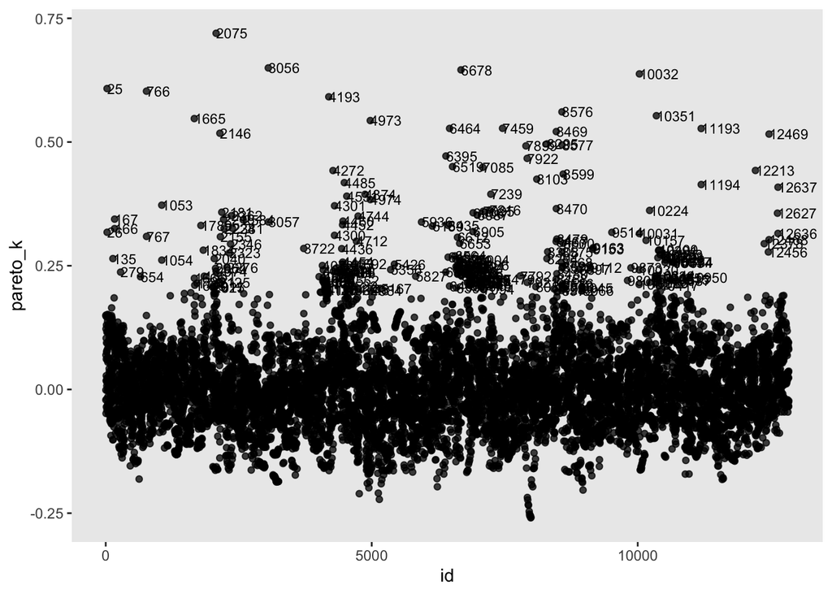

```r
loo(model_M4)$diagnostics %>%
  data.frame() %>%
  # attach the `id` values
  bind_cols(M4_data) %>%
  mutate(id = 1:n()) %>%

  ggplot(aes(x = id, y = pareto_k)) +
  geom_point(alpha = 3/4) +
  geom_text(data = . %>% filter(pareto_k > .2),
            aes(x = id + 2, label = id),
            size = 3, hjust = 0) +
  theme(panel.grid = element_blank())
```

## Visualize posterior distributions of the effects of congruent and incongruent primes on cloglog-hazard relative to blank prime, for each time bin in trials 500, 1000, and 1500.

```r
#get_variables(model_M4)[1:31]

post <-as_draws_df(model_M4) %>% # 8000 draws x 715 variables
   select(starts_with("b_")) %>%       # 8000 x 31
   expand_grid(period_9 = -3:6) %>%
   mutate(period_9sq = period_9^2,
          period_9cu = period_9^3,
          trial500 = -500/1000,
          trial500sq = trial500^2,
          trial1500 = 500/1000,
          trial1500sq = trial1500^2)
# effects for trials 500, 1000, and 1500
effects <- post %>%
  mutate(`congruent trial 1500` = b_conditioncongruent + period_9 * `b_conditioncongruent:period_9` +
            period_9sq * `b_conditioncongruent:Iperiod_9E2` + period_9cu * `b_conditioncongruent:Iperiod_9E3` +
            trial1500 * `b_conditioncongruent:trial_c` + trial1500sq * `b_conditioncongruent:Itrial_cE2` +
            period_9 * trial1500 * `b_conditioncongruent:period_9:trial_c` +
            period_9sq * trial1500 * `b_conditioncongruent:Iperiod_9E2:trial_c` +
            period_9 * trial1500sq * `b_conditioncongruent:period_9:Itrial_cE2` +
            period_9sq * trial1500sq * `b_conditioncongruent:Iperiod_9E2:Itrial_cE2`,

         `incongruent trial 1500` = b_conditionincongruent + period_9 * `b_conditionincongruent:period_9` +
            period_9sq * `b_conditionincongruent:Iperiod_9E2` + period_9cu * `b_conditionincongruent:Iperiod_9E3` +
            trial1500 * `b_conditionincongruent:trial_c` + trial1500sq * `b_conditionincongruent:Itrial_cE2` +
            period_9 * trial1500 * `b_conditionincongruent:period_9:trial_c` +
            period_9sq * trial1500 * `b_conditionincongruent:Iperiod_9E2:trial_c` +
            period_9 * trial1500sq * `b_conditionincongruent:period_9:Itrial_cE2` +
            period_9sq * trial1500sq * `b_conditionincongruent:Iperiod_9E2:Itrial_cE2`,

         `congruent trial 500` = b_conditioncongruent + period_9 * `b_conditioncongruent:period_9` +
            period_9sq * `b_conditioncongruent:Iperiod_9E2` + period_9cu * `b_conditioncongruent:Iperiod_9E3` +
            trial500 * `b_conditioncongruent:trial_c` + trial500sq * `b_conditioncongruent:Itrial_cE2` +
            period_9 * trial500 * `b_conditioncongruent:period_9:trial_c` +
            period_9sq * trial500 * `b_conditioncongruent:Iperiod_9E2:trial_c` +
            period_9 * trial500sq * `b_conditioncongruent:period_9:Itrial_cE2` +
            period_9sq * trial500sq * `b_conditioncongruent:Iperiod_9E2:Itrial_cE2`,

         `incongruent trial 500` = b_conditionincongruent + period_9 * `b_conditionincongruent:period_9` +
            period_9sq * `b_conditionincongruent:Iperiod_9E2` + period_9cu * `b_conditionincongruent:Iperiod_9E3` +
            trial500 * `b_conditionincongruent:trial_c` + trial500sq * `b_conditionincongruent:Itrial_cE2` +
            period_9 * trial500 * `b_conditionincongruent:period_9:trial_c` +
            period_9sq * trial500 * `b_conditionincongruent:Iperiod_9E2:trial_c` +
            period_9 * trial500sq * `b_conditionincongruent:period_9:Itrial_cE2` +
            period_9sq * trial500sq * `b_conditionincongruent:Iperiod_9E2:Itrial_cE2`,

         `congruent trial 1000` = b_conditioncongruent + period_9 * `b_conditioncongruent:period_9` +
            period_9sq * `b_conditioncongruent:Iperiod_9E2` + period_9cu * `b_conditioncongruent:Iperiod_9E3`,

         `incongruent trial 1000` = b_conditionincongruent + period_9 * `b_conditionincongruent:period_9` +
            period_9sq * `b_conditionincongruent:Iperiod_9E2` + period_9cu * `b_conditionincongruent:Iperiod_9E3`)
```

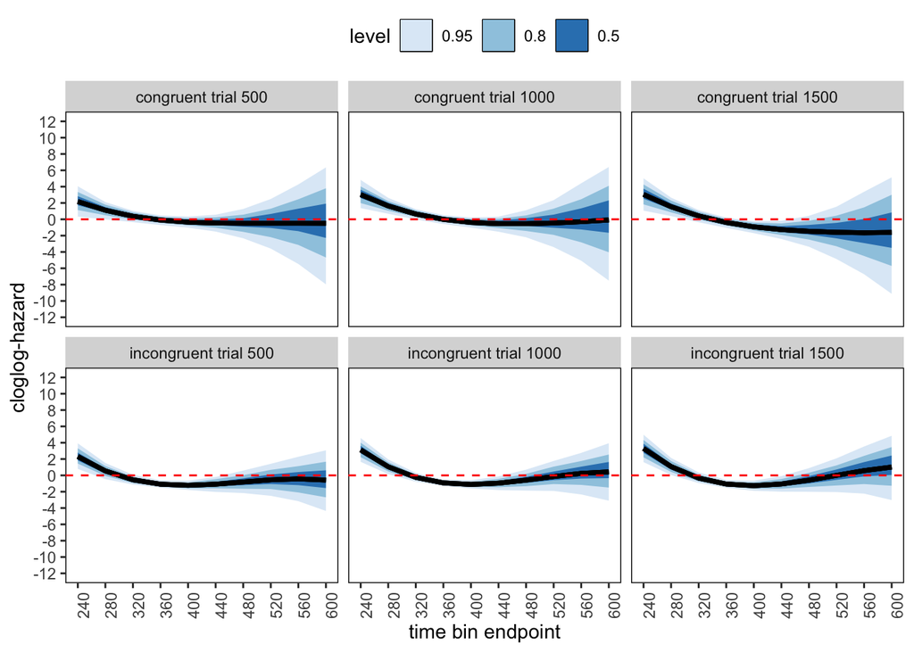

```r
plot_facet <- effects %>%
  pivot_longer(cols=`congruent trial 1500`:`incongruent trial 1000`, names_to = "condition" ) %>%
  select(condition, period_9, value) %>%
  group_by(period_9) %>%

  ggplot(aes(x = period_9, y = value)) +
  stat_lineribbon(point_interval = mean_hdi,.width = c(0.5, 0.8, 0.95),show.legend=T) +
  scale_fill_brewer() +
  geom_hline(yintercept=0, linetype="dashed", color = "red") +
  scale_x_continuous(breaks = c(-3:6), labels=c(((-3:6)+9)*40),
                     limits = c(-3,6)) +
  scale_y_continuous(breaks = c(-12,-10,-8,-6,-4,-2,0,2,4,6,8,10,12), limits = c(-12,12)) +
  labs(x = "time bin endpoint", y = "cloglog-hazard") +
  theme(panel.grid = element_blank(),
        axis.text.x = element_text(angle=90),
        panel.background = element_rect(fill="white", color="black"),
        legend.position = "top") +
  facet_wrap(~ factor(condition,levels=c("congruent trial 500","congruent trial 1000","congruent trial 1500","incongruent trial 500","incongruent trial 1000","incongruent trial 1500")))

plot_facet
```

```r
ggsave("Tutorial_2_Bayesian/figures/M4effects_con_incon_3trials.png", width = 8, height = 8, dpi = 300)
```

## calculate point and interval estimates, and hazard ratios.

```r
int_c_500 <- effects %>%
  select(`congruent trial 500`, period_9) %>%
  group_by(period_9) %>%
  mean_hdi() %>%
  mutate(bin_endpoint = (period_9 + 9)*40,
        `hazard ratio` = exp(`congruent trial 500`),
         mean = `congruent trial 500`,
         condition = "c500") %>%
  select(bin_endpoint,condition, mean, .lower, .upper, .width, `hazard ratio`)

int_i_500 <- effects %>%
  select(`incongruent trial 500`, period_9) %>%
  group_by(period_9) %>%
  mean_hdi() %>%
  mutate(bin_endpoint = (period_9 + 9)*40,
        `hazard ratio` = exp(`incongruent trial 500`),
         mean = `incongruent trial 500`,
         condition = "i500") %>%
  select(bin_endpoint, condition,mean, .lower, .upper, .width, `hazard ratio`)

int_c_1000 <- effects %>%
  select(`congruent trial 1000`, period_9) %>%
  group_by(period_9) %>%
  mean_hdi() %>%
  mutate(bin_endpoint = (period_9 + 9)*40,
        `hazard ratio` = exp(`congruent trial 1000`),
         mean = `congruent trial 1000`,
         condition = "c1000" ) %>%
  select(bin_endpoint,condition,mean, .lower, .upper, .width, `hazard ratio`)

int_i_1000 <- effects %>%
  select(`incongruent trial 1000`, period_9) %>%
  group_by(period_9) %>%
  mean_hdi() %>%
  mutate(bin_endpoint = (period_9 + 9)*40,
        `hazard ratio` = exp(`incongruent trial 1000`),
         mean = `incongruent trial 1000`,
         condition = "i1000") %>%
  select(bin_endpoint, condition,mean, .lower, .upper, .width,`hazard ratio`)

int_c_1500 <- effects %>%
  select(`congruent trial 1500`, period_9) %>%
  group_by(period_9) %>%
  mean_hdi() %>%
  mutate(bin_endpoint = (period_9 + 9)*40,
        `hazard ratio` = exp(`congruent trial 1500`),
         mean = `congruent trial 1500`,
         condition = "c1500" ) %>%
  select(bin_endpoint, condition, mean, .lower, .upper, .width, `hazard ratio`)

int_i_1500 <- effects %>%
  select(`incongruent trial 1500`, period_9) %>%
  group_by(period_9) %>%
  mean_hdi() %>%
  mutate(bin_endpoint = (period_9 + 9)*40,
        `hazard ratio` = exp(`incongruent trial 1500`),
         mean = `incongruent trial 1500`,
         condition = "i1500") %>%
  select(bin_endpoint, condition,mean, .lower, .upper, .width,  `hazard ratio`)

test <- rbind(int_c_500, int_c_1000, int_c_1500,int_i_500,int_i_1000, int_i_1500)
test %>% print(n=60)
```

```
## # A tibble: 60 × 7
##    bin_endpoint condition     mean   .lower  .upper .width `hazard ratio`
##           <dbl> <chr>        <dbl>    <dbl>   <dbl>  <dbl>          <dbl>
##  1          240 c500       2.18      0.332   4.05     0.95          8.82
##  2          280 c500       1.11     -0.0162  2.11     0.95          3.03
##  3          320 c500       0.374    -0.342   1.04     0.95          1.45
##  4          360 c500      -0.0900   -0.704   0.476    0.95          0.914
##  5          400 c500      -0.345    -1.02    0.336    0.95          0.708
##  6          440 c500      -0.454    -1.50    0.564    0.95          0.635
##  7          480 c500      -0.477    -2.32    1.27     0.95          0.620
##  8          520 c500      -0.478    -3.57    2.52     0.95          0.620
##  9          560 c500      -0.518    -5.69    4.27     0.95          0.595
## 10          600 c500      -0.660    -8.56    6.99     0.95          0.517
## 11          240 c1000      3.03      1.37    4.82     0.95         20.6
## 12          280 c1000      1.63      0.681   2.63     0.95          5.13
```

[output cut: 48 more lines]

```r
write_csv(test, file="Tutorial_2_Bayesian/tables/effects_intervals_table.csv")
```

## Plot model-based predicted cloglog-hazard and hazard functions, for a single subject.

```r
selected_subject = 6 # select pid here (1:6) manually
```

```r
make_fitted <- function(fit, scale, ...) {

  fitted(fit,
         newdata = nd,
         scale = scale,
         ...) %>%
    data.frame() %>%
    bind_cols(nd)
}
```

### Set up new data.

```r
# define the `newdata`
nd <- tibble(pid = 1:6) %>%
  expand_grid(incon = 0:1,
                con  = 0:1,
                trial_c = c(-0.5,0,0.5),
                period_9 = -3:6) %>%
  filter(!(con ==1 & incon == 1)) %>%
  mutate(Iperiod_9E2 = period_9^2,
         Iperiod_9E3 = period_9^3,
         Itrial_cE2 = trial_c^2,
         condition = ifelse(con==1 & incon==0,"congruent",
                     ifelse(con==0 & incon==1,"incongruent", "blank")),
         condition = factor(condition, levels=c("blank" ,"congruent","incongruent")))
```

### First, on the cloglog-scale.

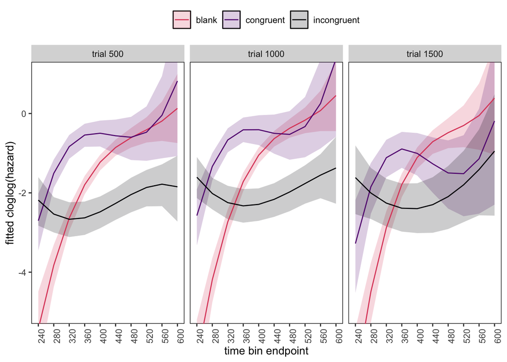

```r
make_fitted(model_M4, scale = "linear") %>%
  mutate(cond   = rep(rep(c("N","C","I"),each=30),6),
         trial  = factor(trial_c,levels=c(-0.5,0.0,0.5),labels=c("trial 500","trial 1000","trial 1500")),
         period = period_9+9) %>%
  filter(pid==selected_subject) %>%
  # plot
  ggplot(aes(x = period, y = Estimate, ymin = Q2.5, ymax = Q97.5,
             fill = condition, color = condition)) +
  geom_ribbon(alpha = 1/5, linewidth = 0) +
  geom_line() +
  scale_fill_viridis_d(NULL, option = "A", end = .6, direction = -1) +
  scale_color_viridis_d(NULL, option = "A", end = .6, direction = -1) +
  scale_x_continuous("time bin endpoint", breaks = 6:15, limits = c(6, 15), labels=c(6:15)*40) +
  ylab("fitted cloglog(hazard)") +
  coord_cartesian(ylim = c(-5, 1)) +
  theme(panel.grid = element_blank(),
        panel.background = element_rect(fill="white",color="black"),
        legend.position = "top",
        axis.text.x = element_text(angle=90)) +
  facet_wrap(~ trial)
```

### Second, on hazard scale.

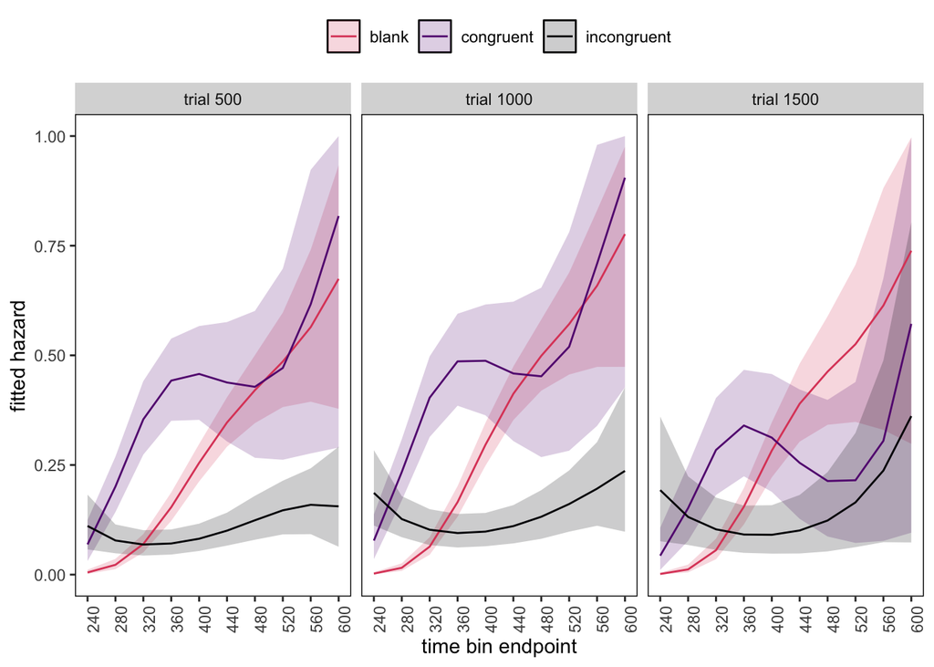

```r
make_fitted(model_M4, scale = "response") %>%
  mutate(cond   = rep(rep(c("N","C","I"),each=30),6),
         trial  = factor(trial_c,levels=c(-0.5,0.0,0.5),labels=c("trial 500","trial 1000","trial 1500")),
         period = period_9+9) %>%
  filter(pid==selected_subject) %>%
  # plot
  ggplot(aes(x = period, y = Estimate, ymin = Q2.5, ymax = Q97.5,
             fill = condition, color = condition)) +
  geom_ribbon(alpha = 1/5, linewidth = 0) +
  geom_line() +
  scale_fill_viridis_d(NULL, option = "A", end = .6, direction = -1) +
  scale_color_viridis_d(NULL, option = "A", end = .6, direction = -1) +
  scale_x_continuous("time bin endpoint", breaks = 6:15, limits = c(6, 15), labels=c(6:15)*40) +
  ylab("fitted hazard") +
  coord_cartesian(ylim = c(0, 1)) +
  theme(panel.grid = element_blank(),
        panel.background = element_rect(fill="white",color="black"),
        legend.position = "top",
        axis.text.x = element_text(angle=90)) +
  facet_wrap(~ trial)
```

```r
ggsave("Tutorial_2_Bayesian/figures/M4effects_subject6.png", width = 10, height = 10, dpi = 300)
```